# Отчёт по лабораторной работе №6

Установка и настройка СУБД MariaDB

Элсаиед Адел

Российский университет дружбы народов, Москва, Россия

3 января 2026

# Цели и задачи работы

## Цель лабораторной работы

Приобретение практических навыков по установке и конфигурированию системы управления базами данных на примере MariaDB.

# Выполнение работы

## Установка пакетов MariaDB

На виртуальной машине `server` выполнена установка серверной и клиентской части MariaDB.

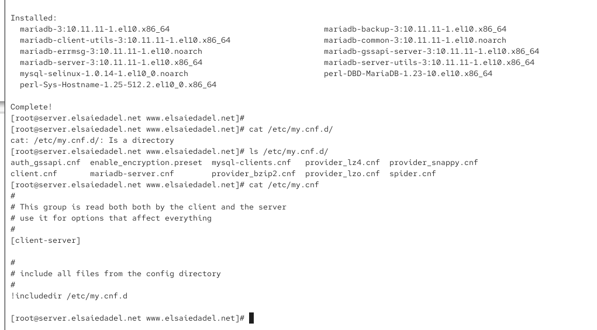

Установка пакетов MariaDB

## Запуск и автозагрузка службы

Служба MariaDB запущена и включена в автозагрузку:

- `systemctl start mariadb`
- `systemctl enable mariadb`

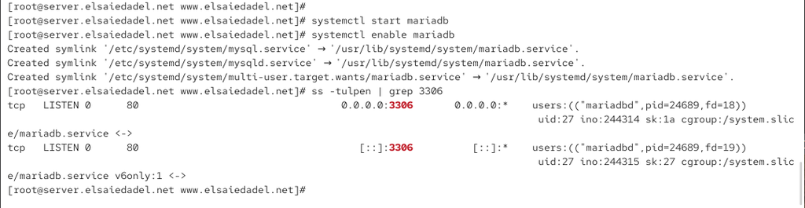

Запуск и enable mariadb

## Проверка прослушивания порта 3306

Проверено, что процесс `mariadbd` слушает порт `3306`:

- `ss -tulpen | grep 3306`

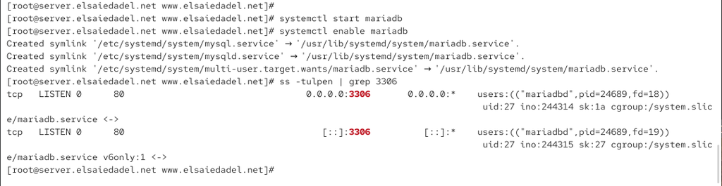

Проверка порта 3306

## mysql_secure_installation

Выполнено: - настройка root-доступа (в т.ч. unix_socket) - установка пароля root MariaDB - применение обновлений таблиц привилегий

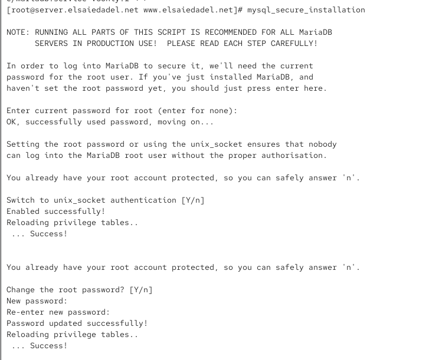

mysql_secure_installation

## Проверка окружения MariaDB

В интерактивной оболочке проверены: - справка: `\h` - системные базы: `SHOW DATABASES;`

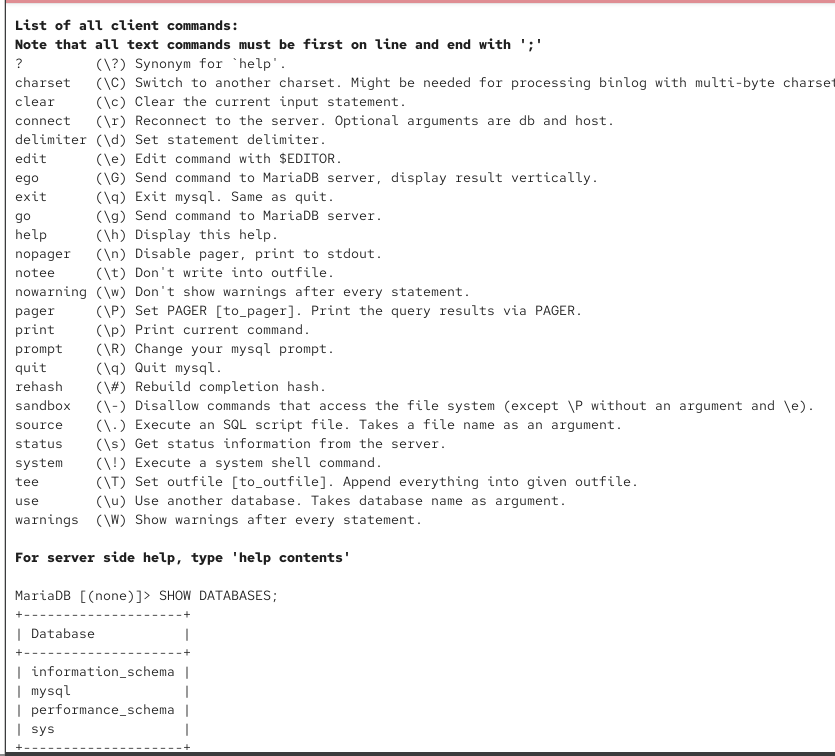

Справка и SHOW DATABASES

## Статус до изменения кодировки

Команда `status` показала, что серверная кодировка по умолчанию была `latin1`.

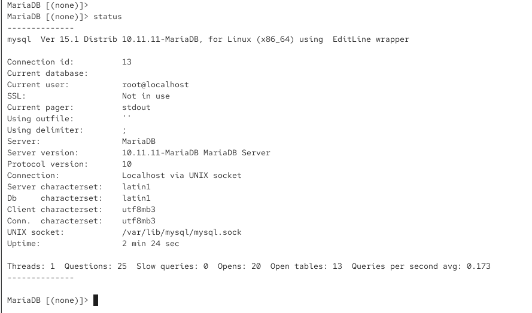

status до настройки UTF-8

## Настройка UTF-8 через utf8.cnf

Создан файл `/etc/my.cnf.d/utf8.cnf`:

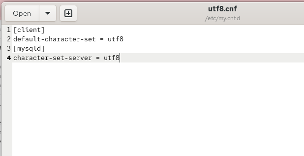

Файл utf8.cnf

## Статус после перезапуска MariaDB

Изменения: - `Server characterset`: `latin1` → `utf8mb3` - `Db characterset`: `latin1` → `utf8mb3`

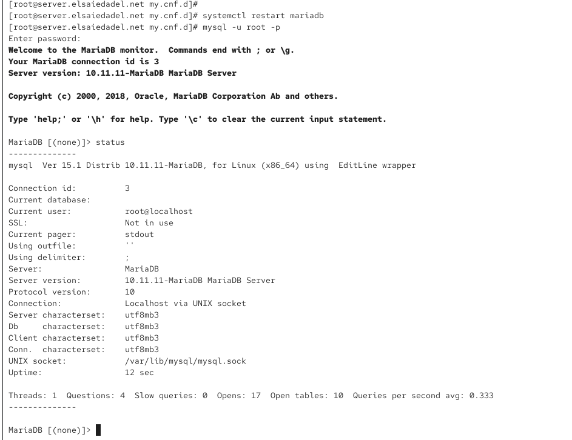

status после настройки UTF-8

## Создание базы и таблицы

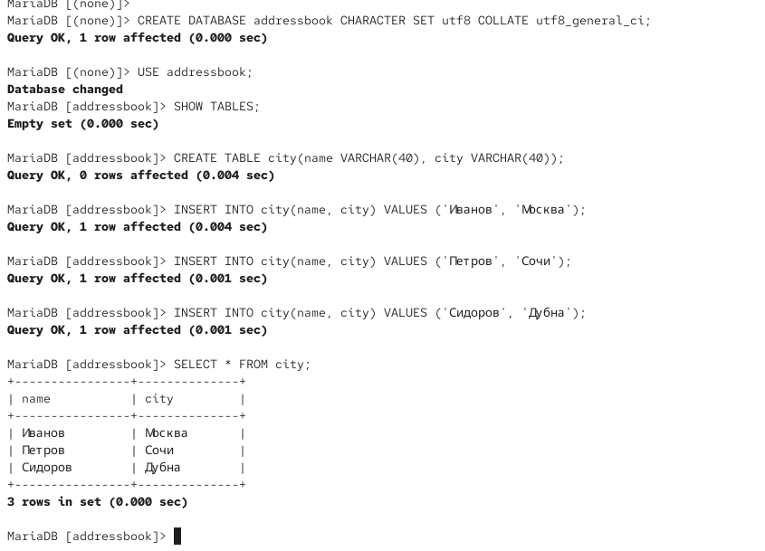

SELECT * FROM city

## Создание пользователя и выдача прав

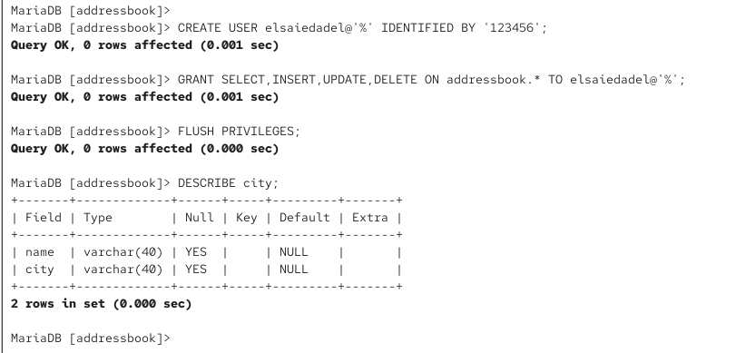

Пользователь, GRANT, DESCRIBE

## Проверка структуры таблицы и объектов

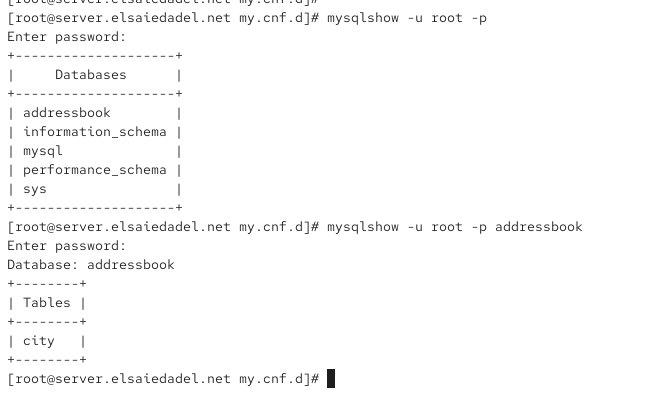

mysqlshow: базы и таблицы

## Резервные копии mysqldump

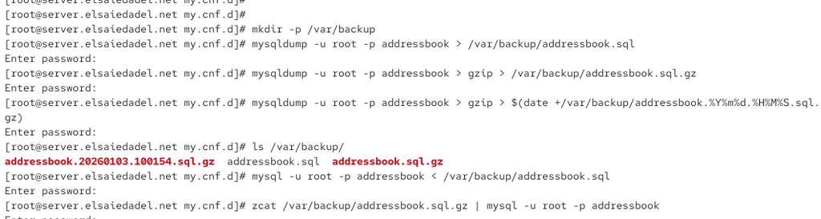

Backup/Restore addressbook

## Подготовка файлов для provisioning

Созданы каталоги в `/vagrant/provision/server`: - `mysql/etc/my.cnf.d` - `mysql/var/backup`

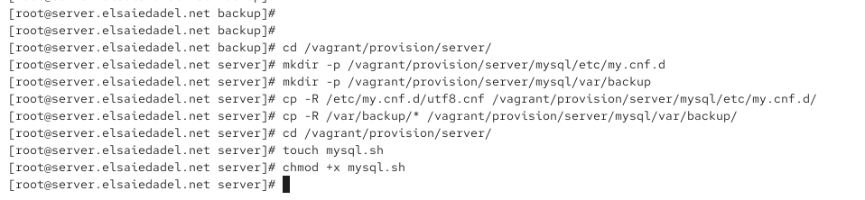

Копирование конфигурации и резервных копий

## Скрипт mysql.sh

Создан исполняемый скрипт `mysql.sh`, который повторяет выполненные шаги:

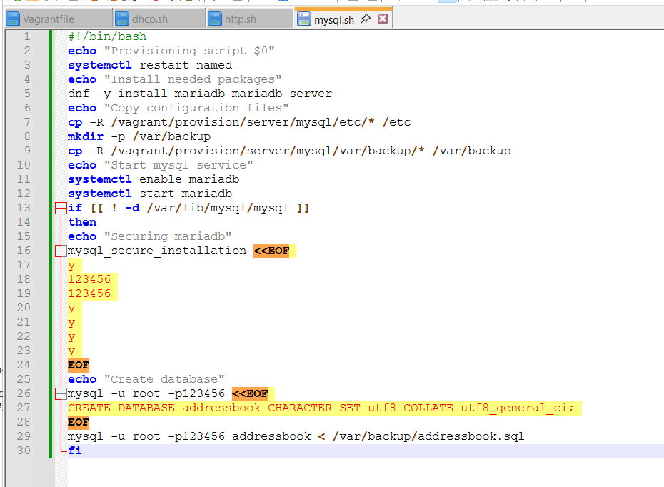

mysql.sh (provisioning)

# Выводы

## Вывод

В ходе лабораторной работы выполнена установка и настройка MariaDB на виртуальной машине: применены базовые меры безопасности, настроена кодировка UTF-8, создана пользовательская база `addressbook`, реализовано управление доступом и проверены операции резервного копирования/восстановления. Дополнительно подготовлен provisioning-скрипт, автоматизирующий установку и конфигурацию, что повышает воспроизводимость и упрощает развёртывание серверного окружения.